# Financial Analytics

Fatos Estilizados e Modelos de Volatilidade

Paloma Vaissman Uribe

Insper, PADS

Julio Trecenti

2026

## 🎯 Objetivos desta Aula

Ao final você será capaz de:

- **Identificar** os fatos estilizados dos retornos financeiros
- **Distinguir** preços (não estacionários) de retornos (estacionários)
- **Testar** efeitos ARCH via Ljung-Box e teste LM
- **Estimar** modelos ARCH(m) e GARCH(m,n) com Python
- **Comparar** extensões: IGARCH, EGARCH e TGARCH
- **Avaliar** volatilidade via janelas móveis e SV

## 📌 Estrutura da Aula

**Parte 1: Fatos Estilizados**

- Motivação: heterocedasticidade
- Log-retornos: definição e cálculo
- Fato 1: não normalidade
- Fato 2: estacionaridade
- Fato 3: clusters de volatilidade
- Testes ARCH (Ljung-Box, LM)

**Parte 2: Modelos de Volatilidade**

- Notação e variância condicional
- ARCH(m): definição e desvantagens
- GARCH(m,n): solução parcimonosa
- Estimação e diagnóstico
- Janelas móveis
- Extensões: IGARCH, EGARCH, TGARCH
- Volatilidade Estocástica (SV)

# Parte 1 · Fatos Estilizados

*Por que retornos e não preços?*

## 1 · Motivação: Heterocedasticidade Condicional

Dados financeiros exibem **aglomeração de volatilidade** (*volatility clustering*):

> Períodos de **baixa volatilidade** se alternam com períodos de **alta volatilidade**, e isso persiste no tempo.

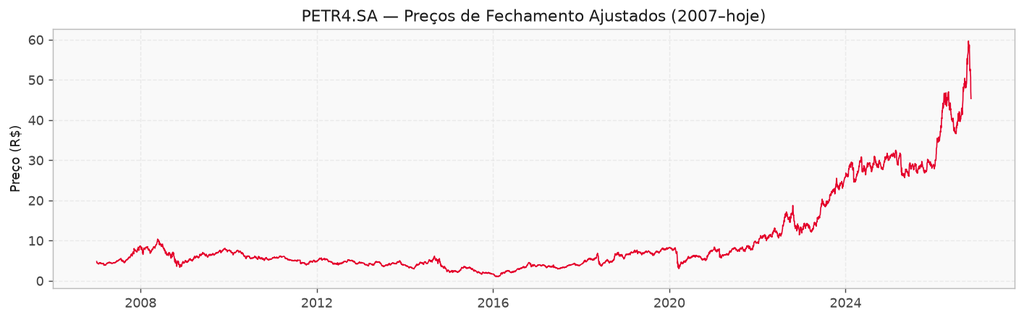

**Nota**

Preços de ativos são **não estacionários**: exibem tendência e variância crescente.  
Por isso analisamos os **log-retornos** em vez dos preços diretamente.

## 2 · Carregando Dados com `yfinance`

```python
import yfinance as yf
import pandas as pd
import numpy as np

# Baixar dados reais da PETR4.SA desde 2007
data = yf.download('PETR4.SA',
                   start='2007-01-01',
                   auto_adjust=True,
                   progress=False)

prices = data['Close'].squeeze()
print(prices.tail())
```

**Dica**

`auto_adjust=True` já corrige por dividendos e splits.  
Use `.squeeze()` para garantir que o resultado seja uma `Series`.

## 2 · Log-Retornos

Os **log-retornos** são definidos como:

$$r_t = \log\left(\frac{P_t}{P_{t-1}}\right) = \log(P_t) - \log(P_{t-1})$$

```python
# Calcular log-retornos
ret = np.log(prices / prices.shift(1)).dropna()

print(f"Observações:   {len(ret)}")
print(f"Média:         {ret.mean():.6f}")
print(f"Desvio padrão: {ret.std():.4f}")
print(f"Mínimo:        {ret.min():.4f}")
print(f"Máximo:        {ret.max():.4f}")
```

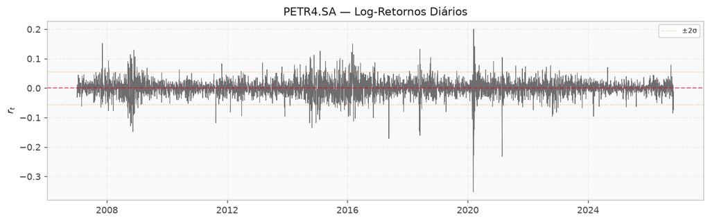

## 3 · Fato 1: Não Normalidade

```python
from scipy import stats

# Estatísticas descritivas
print(f"Assimetria:  {ret.skew():.4f}  (Normal: 0)")
print(f"Curtose:     {ret.kurtosis():.4f}  (Normal: 0)")

# Shapiro-Wilk exige n ≤ 5000, amostra com semente fixa
stat, pval = stats.shapiro(ret.sample(5000, random_state=42))
print(f"Shapiro-Wilk: W={stat:.4f}  p-value={pval:.2e}")
```

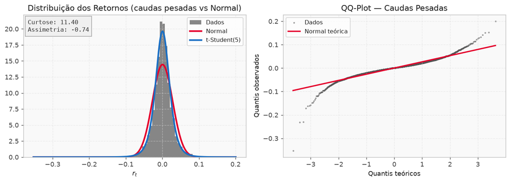

## 3 · Fato 1: Curtose e Caudas Pesadas

A curtose em excesso dos retornos é tipicamente **alta** (> 3 para dados reais):

[output not shown]

**Aviso**

Curtose alta = **caudas muito mais pesadas** que a Normal.  
Eventos extremos (crashes, rallies) ocorrem **muito mais frequentemente** do que a Normal prevê.  
Usar Normal em modelos de risco (VaR) **subestima sistematicamente** as perdas extremas.

## 3 · Fatos 2 e 3: Estacionaridade e Clusters

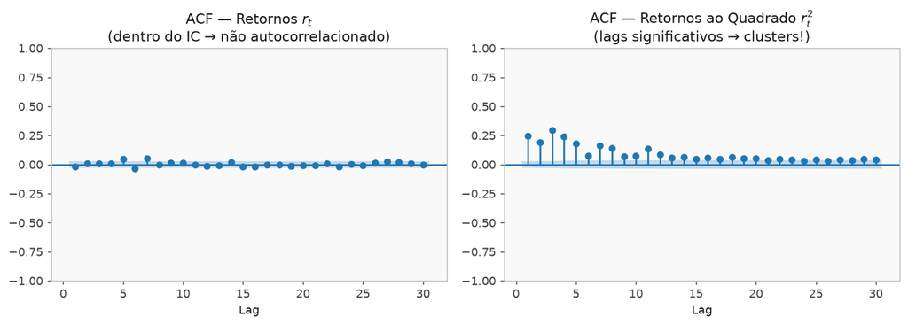

## 3 · Clusters de Volatilidade

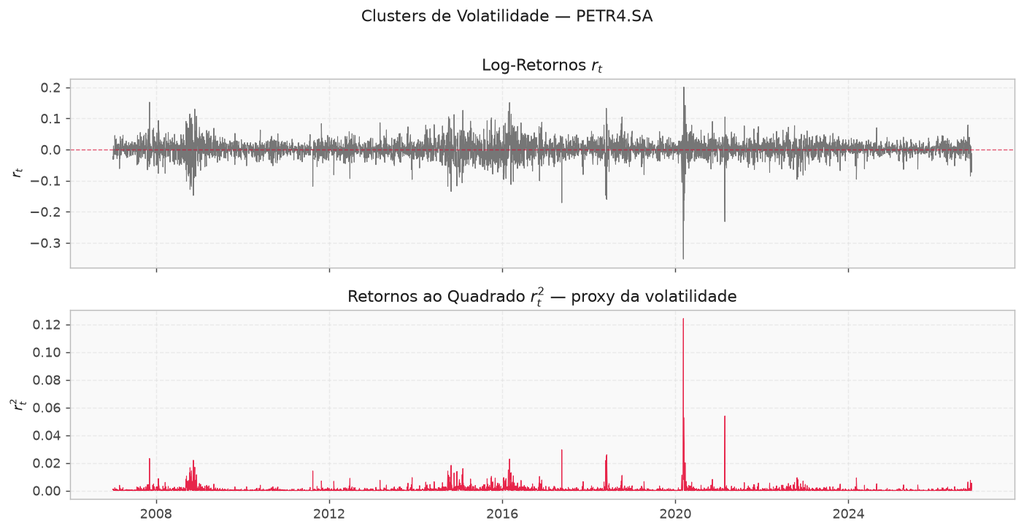

**Nota**

$r_t^2$ é um **proxy da volatilidade instantânea**.  
A ACF de $r_t^2$ decaindo lentamente indica **memória na volatilidade**, o que motiva os modelos ARCH/GARCH.

## 4 · Testando Efeitos ARCH

**Teste Ljung-Box** em $r_t^2$:

$$H_0: \rho_1(r^2) = \cdots = \rho_k(r^2) = 0 \quad \text{(sem autocorrelação)}$$

```python
from statsmodels.stats.diagnostic import acorr_ljungbox

# Ljung-Box nos retornos ao quadrado
lb = acorr_ljungbox(ret**2, lags=[12], return_df=True)
print(lb)
# p-value << 0.05 → rejeita H₀ → há efeitos ARCH
```

**Teste LM (Lagrange Multiplier)**:

$$H_0: \alpha_1 = \cdots = \alpha_m = 0 \quad \text{(sem efeitos ARCH)}$$

```python
from arch import arch_model

# Teste LM via arch
am = arch_model(ret, vol='ARCH', p=12)
res = am.fit(disp='off')
print(res.arch_lm_test(lags=12))
```

## 4 · Resultados dos Testes ARCH

**Dica**

**Regra prática:** sempre teste efeitos ARCH **antes** de ajustar um modelo GARCH.  
Se os testes não rejeitarem H₀, um modelo simples de média (ARMA) já é suficiente.

# Parte 2 · Modelos de Volatilidade

*ARCH, GARCH e extensões*

## 5 · Notação Básica

Seja $r_t$ uma série de retornos. Condicionalmente à informação até $t-1$ ($\Omega_{t-1}$):

$$\mu_t = E(r_t \,|\, \Omega_{t-1}) \quad \text{(média condicional)}$$

$$h_t = E\!\left[(r_t - \mu_t)^2 \,|\, \Omega_{t-1}\right] \quad \text{(variância condicional = volatilidade)}$$

O modelo geral é:

$$r_t = \mu_t + \sqrt{h_t}\,\varepsilon_t, \quad \varepsilon_t \sim i.i.d.(0,1)$$

**Nota**

$\varepsilon_t$ pode seguir distribuição **Normal**, **t-Student** ou **GED**.  
Na prática, t-Student é preferível por ter **caudas mais pesadas**, compatível com o Fato 1.

## 6 · Modelo ARCH(m)

Introduzido por **Engle (1982)**. A volatilidade depende dos $m$ retornos passados ao quadrado:

$$r_t = \mu_t + \sqrt{h_t}\,\varepsilon_t$$

$$h_t = \alpha_0 + \alpha_1 r_{t-1}^2 + \alpha_2 r_{t-2}^2 + \cdots + \alpha_m r_{t-m}^2$$

com $\alpha_0 > 0$ e $\alpha_i \geq 0$ para $i = 1, \ldots, m$.

**Aviso**

**Desvantagens do ARCH(m):** requer muitos parâmetros para capturar persistência, trata choques positivos e negativos **simetricamente**, e superestima a volatilidade após grandes choques isolados.

## 6 · Ajustando ARCH(12) com Python

```python
from arch import arch_model

# ARCH(12) com distribuição Normal
m1 = arch_model(ret, mean='Constant', vol='ARCH', p=12, dist='normal')
res1 = m1.fit(disp='off')
print(res1.summary())
```

## 6 · ARCH(12) com Erros t-Student

```python
# ARCH(12) com distribuição t-Student (caudas mais pesadas)
m2 = arch_model(ret, mean='Constant', vol='ARCH', p=12, dist='t')
res2 = m2.fit(disp='off')

# Comparar AIC/BIC
print(f"ARCH(12) Normal | AIC: {res1.aic:.1f}  BIC: {res1.bic:.1f}")
print(f"ARCH(12) t-Student | AIC: {res2.aic:.1f}  BIC: {res2.bic:.1f}")
```

**Dica**

**Seleção de distribuição:** compare o AIC/BIC entre Normal e t-Student.  
Em dados financeiros, **t-Student quase sempre vence**, compatível com as caudas pesadas do Fato 1.

## 7 · Modelo GARCH(m,n)

**Bollerslev (1986)**: resolve o problema de parcimônia do ARCH adicionando lags da própria variância:

$$h_t = \alpha_0 + \underbrace{\sum_{i=1}^{m}\alpha_i\, r_{t-i}^2}_{\text{termos ARCH}} + \underbrace{\sum_{j=1}^{n}\beta_j\, h_{t-j}}_{\text{termos GARCH}}$$

Restrição de estacionaridade: $\displaystyle\sum_{i=1}^{m}\alpha_i + \sum_{j=1}^{n}\beta_j < 1$

**GARCH(1,1)**, o modelo mais usado na prática:

$$h_t = \alpha_0 + \alpha_1 r_{t-1}^2 + \beta_1 h_{t-1}$$

## 7 · Ajustando GARCH(1,1)

```python
# GARCH(1,1) com distribuição Normal
m3 = arch_model(ret, mean='Constant', vol='GARCH', p=1, q=1, dist='normal')
res3 = m3.fit(disp='off')

# GARCH(1,1) com distribuição t-Student (preferível)
m4 = arch_model(ret, mean='Constant', vol='GARCH', p=1, q=1, dist='t')
res4 = m4.fit(disp='off')

print(res4.params)
```

**Nota**

$\alpha_1 + \beta_1$ muito próximo de 1 indica alta **persistência**: choques na volatilidade demoram a dissipar.

## 7 · Volatilidade Estimada GARCH(1,1)

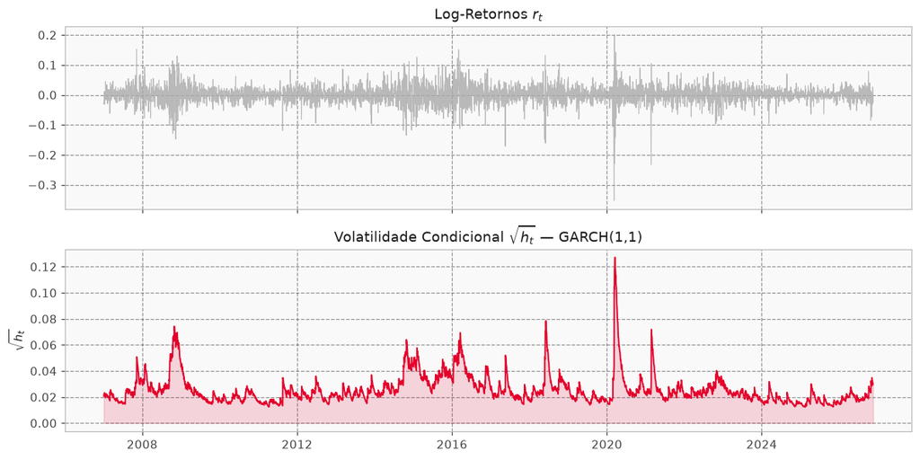

## 7 · ARCH(12) vs GARCH(1,1)

```python
print(f"{'Modelo':30s}  {'AIC':>10}  {'BIC':>10}  {'Parâmetros':>10}")
print('-'*66)
for nome, res in [('ARCH(12) Normal', res1), ('ARCH(12) t-Student', res2),
                   ('GARCH(1,1) Normal', res3), ('GARCH(1,1) t-Student', res4)]:
    print(f"{nome:30s}  {res.aic:10.1f}  {res.bic:10.1f}  {len(res.params):10d}")
```

**Dica**